# BAN110 Group project - Heart disease dataset

```sas
*Reading dataset;
libname mylib '/folders/myfolders/ban110/group_project';

FILENAME REFFILE '/folders/myfolders/ban110/group_project/heart.csv';

PROC IMPORT DATAFILE=REFFILE
    DBMS=CSV
    OUT= mylib.heart replace;
    GETNAMES=YES;
RUN;

*ignore the error because it is about the missing value;
```

[output not shown]

[output cut: 72 more lines]

[output not shown]

```sas
*label the dataset;
data mylib.heart;
    set mylib.heart;
    label
        age ="age in years"
        sex="Gender (1 Male, 0 Female)"
        cp="chest pain type (4 values)"
        trestbps = "resting blood pressure (in mm Hg on admission to the hospital)"
        chol="serum cholestoral in mg/dl"
        fbs="(fasting blood sugar > 120 mg/dl) (1 = true; 0 = false)"
        restecg="restecg: resting electrocardiographic results
                (0: normal, 1: having ST-T wave abnormality (T wave inversions and/or ST elevation or depression of > 0.05 mV)
                ,2: showing probable or definite left ventricular hypertrophy by Estes' criteria)"
        thalach="maximum heart rate achieved"
        exang="exercise induced angina (1 = yes; 0 = no)"
        oldpeak="ST depression induced by exercise relative to rest"
        slope="the slope of the peak exercise ST segment (1 Upsloping, 2 flat, 3 downsloping)"
        ca="number of major vessels (0-3) colored by flourosopy"
        thal="3 = normal; 6 = fixed defect; 7 = reversable defect"
        target= "presence of heart disease in the patient with integer value 0-4";
run;

*create id field;
data mylib.heart;
    retain id;
    set mylib.heart;
    id = _n_;
run;

title "First 15 rows from dataset";
proc print data=mylib.heart (obs=15);
run;
```

First 15 rows from dataset

| Obs | id | age | sex | cp | trestbps | chol | fbs | restecg | thalach | exang | oldpeak | slope | ca | thal | target |
| --- | --- | --- | --- | --- | --- | --- | --- | --- | --- | --- | --- | --- | --- | --- | --- |
| 1 | 1 | 63 | 1 | 1 | 145 | 233 | 1 | 2 | 150 | 0 | 2.3 | 3 | 0 | 6 | 0 |
| 2 | 2 | 67 | 1 | 4 | 160 | 286 | 0 | 2 | 108 | 1 | 1.5 | 2 | 3 | 3 | 2 |
| 3 | 3 | 67 | 1 | 4 | 120 | 229 | 0 | 2 | 129 | 1 | 2.6 | 2 | 2 | 7 | 1 |
| 4 | 4 | 37 | 1 | 3 | 130 | 250 | 0 | 0 | 187 | 0 | 3.5 | 3 | 0 | 3 | 0 |
| 5 | 5 | 41 | 0 | 2 | 130 | 204 | 0 | 2 | 172 | 0 | 1.4 | 1 | 0 | 3 | 0 |
| 6 | 6 | 56 | 1 | 2 | 120 | 236 | 0 | 0 | 178 | 0 | 0.8 | 1 | 0 | 3 | 0 |
| 7 | 7 | 62 | 0 | 4 | 140 | 268 | 0 | 2 | 160 | 0 | 3.6 | 3 | 2 | 3 | 3 |
| 8 | 8 | 57 | 0 | 4 | 120 | 354 | 0 | 0 | 163 | 1 | 0.6 | 1 | 0 | 3 | 0 |
| 9 | 9 | 63 | 1 | 4 | 130 | 254 | 0 | 2 | 147 | 0 | 1.4 | 2 | 1 | 7 | 2 |
| 10 | 10 | 53 | 1 | 4 | 140 | 203 | 1 | 2 | 155 | 1 | 3.1 | 3 | 0 | 7 | 1 |
| 11 | 11 | 57 | 1 | 4 | 140 | 192 | 0 | 0 | 148 | 0 | 0.4 | 2 | 0 | 6 | 0 |
| 12 | 12 | 56 | 0 | 2 | 140 | 294 | 0 | 2 | 153 | 0 | 1.3 | 2 | 0 | 3 | 0 |
| 13 | 13 | 56 | 1 | 3 | 130 | 256 | 1 | 2 | 142 | 1 | 0.6 | 2 | 1 | 6 | 2 |
| 14 | 14 | 44 | 1 | 2 | 120 | 263 | 0 | 0 | 173 | 0 | 0 | 1 | 0 | 7 | 0 |
| 15 | 15 | 52 | 1 | 3 | 172 | 199 | 1 | 0 | 162 | 0 | 0.5 | 1 | 0 | 7 | 0 |

## Dataset characteristic

```sas
title "Contents of the dataset";
proc contents data=mylib.heart order=varnum;
run;

title "Frequency table of target variable";
proc freq data=mylib.heart;
    tables target /  nocum;
run;
```

Contents of the dataset

The CONTENTS Procedure

| Data Set Name | MYLIB.HEART | Observations | 303 |
| --- | --- | --- | --- |
| Member Type | DATA | Variables | 15 |
| Engine | V9 | Indexes | 0 |
| Created | 11/25/2019 00:17:02 | Observation Length | 120 |
| Last Modified | 11/25/2019 00:17:02 | Deleted Observations | 0 |
| Protection |  | Compressed | NO |
| Data Set Type |  | Sorted | NO |
| Label |  |  |  |
| Data Representation | SOLARIS_X86_64, LINUX_X86_64, ALPHA_TRU64, LINUX_IA64 |  |  |
| Encoding | utf-8 Unicode (UTF-8) |  |  |

| Engine/Host Dependent Information |  |
| --- | --- |
| Data Set Page Size | 65536 |
| Number of Data Set Pages | 1 |
| First Data Page | 1 |
| Max Obs per Page | 545 |
| Obs in First Data Page | 303 |
| Number of Data Set Repairs | 0 |
| Filename | /folders/myfolders/ban110/group_project/heart.sas7bdat |
| Release Created | 9.0401M6 |
| Host Created | Linux |
| Inode Number | 153 |
| Access Permission | rwxrwx--- |
| Owner Name | root |
| File Size | 128KB |
| File Size (bytes) | 131072 |

| Variables in Creation Order # | Variables in Creation Order Variable | Variables in Creation Order Type | Variables in Creation Order Len | Variables in Creation Order Format | Variables in Creation Order Informat | Variables in Creation Order Label |
| --- | --- | --- | --- | --- | --- | --- |
| 1 | id | Num | 8 |  |  |  |
| 2 | age | Num | 8 | BEST12. | BEST32. | age in years |
| 3 | sex | Num | 8 | BEST12. | BEST32. | Gender (1 Male, 0 Female) |
| 4 | cp | Num | 8 | BEST12. | BEST32. | chest pain type (4 values) |
| 5 | trestbps | Num | 8 | BEST12. | BEST32. | resting blood pressure (in mm Hg on admission to the hospital) |
| 6 | chol | Num | 8 | BEST12. | BEST32. | serum cholestoral in mg/dl |
| 7 | fbs | Num | 8 | BEST12. | BEST32. | (fasting blood sugar > 120 mg/dl) (1 = true; 0 = false) |
| 8 | restecg | Num | 8 | BEST12. | BEST32. | restecg: resting electrocardiographic results (0: normal, 1: having ST-T wave abnormality (T wave inversions and/or ST elevation or depression of > 0.05 mV) ,2: showing probable or definite left ventr… |
| 9 | thalach | Num | 8 | BEST12. | BEST32. | maximum heart rate achieved |
| 10 | exang | Num | 8 | BEST12. | BEST32. | exercise induced angina (1 = yes; 0 = no) |
| 11 | oldpeak | Num | 8 | BEST12. | BEST32. | ST depression induced by exercise relative to rest |
| 12 | slope | Num | 8 | BEST12. | BEST32. | the slope of the peak exercise ST segment (1 Upsloping, 2 flat, 3 downsloping) |
| 13 | ca | Num | 8 | BEST12. | BEST32. | number of major vessels (0-3) colored by flourosopy |
| 14 | thal | Num | 8 | BEST12. | BEST32. | 3 = normal; 6 = fixed defect; 7 = reversable defect |
| 15 | target | Num | 8 | BEST12. | BEST32. | presence of heart disease in the patient with integer value 0-4 |

Frequency table of target variable

The FREQ Procedure

| presence of heart disease in the patient with integer value 0-4 target | presence of heart disease in the patient with integer value 0-4 Frequency | presence of heart disease in the patient with integer value 0-4 Percent |
| --- | --- | --- |
| 0 | 164 | 54.13 |
| 1 | 55 | 18.15 |
| 2 | 36 | 11.88 |
| 3 | 35 | 11.55 |
| 4 | 13 | 4.29 |

1. Number of instances: 303
2. List of variables names: output of proc contents. Type: All numeric
3. Target varaible: target. Dependent variable: all other variables
4. The dataset is balanced is not balanced (freq for 0 is 54%) -> suggestion: create derived variable: 1-4 -> 1. New variable will be more balances between 2 values 0 and 1.

## Categorical variable

**List of categorical variable in the dataset**

- sex
- cp
- fbs
- restecg
- exang
- slope
- ca
- thal
- target

### Check and correct errors when necessary

#### Var: Sex

```sas
title "Frequency table of sex variable";
proc freq data=mylib.heart;
    tables sex /  nocum;
run;
```

Frequency table of sex variable

The FREQ Procedure

| Gender (1 Male, 0 Female) sex | Gender (1 Male, 0 Female) Frequency | Gender (1 Male, 0 Female) Percent |
| --- | --- | --- |
| 0 | 97 | 32.01 |
| 1 | 206 | 67.99 |

Unbalanced between 2 values, no error in this variable

#### Var: cp

```sas
title "Frequency table of cp variable";
proc freq data=mylib.heart;
    tables cp /  nocum;
run;
```

Frequency table of cp variable

The FREQ Procedure

| chest pain type (4 values) cp | chest pain type (4 values) Frequency | chest pain type (4 values) Percent |
| --- | --- | --- |
| 1 | 23 | 7.59 |
| 2 | 50 | 16.50 |
| 3 | 86 | 28.38 |
| 4 | 144 | 47.52 |

Unbalanced between 4 values, no error in this variable

#### Var: fps

```sas
title "Frequency table of fbs variable";
proc freq data=mylib.heart;
    tables fbs /  nocum;
run;
```

Frequency table of fbs variable

The FREQ Procedure

| (fasting blood sugar > 120 mg/dl) (1 = true; 0 = false) fbs | (fasting blood sugar > 120 mg/dl) (1 = true; 0 = false) Frequency | (fasting blood sugar > 120 mg/dl) (1 = true; 0 = false) Percent |
| --- | --- | --- |
| 0 | 258 | 85.15 |
| 1 | 45 | 14.85 |

Unbalanced, no error

#### Var: restecg

```sas
title "Frequency table of restecg variable";
proc freq data=mylib.heart;
    tables restecg /  nocum;
run;
```

Frequency table of restecg variable

The FREQ Procedure

| restecg: resting electrocardiographic results (0: normal, 1: having ST-T wave abnormality (T wave inversions and/or ST elevation or depression of > 0.05 mV) ,2: showing probable or definite left ventr… restecg | restecg: resting electrocardiographic results (0: normal, 1: having ST-T wave abnormality (T wave inversions and/or ST elevation or depression of > 0.05 mV) ,2: showing probable or definite left ventr… Frequency | restecg: resting electrocardiographic results (0: normal, 1: having ST-T wave abnormality (T wave inversions and/or ST elevation or depression of > 0.05 mV) ,2: showing probable or definite left ventr… Percent |
| --- | --- | --- |
| 0 | 151 | 49.83 |
| 1 | 4 | 1.32 |
| 2 | 148 | 48.84 |

Unbalanced, no error

#### Var: exang

```sas
title "Frequency table of exang variable";
proc freq data=mylib.heart;
    tables exang /  nocum;
run;
```

Frequency table of exang variable

The FREQ Procedure

| exercise induced angina (1 = yes; 0 = no) exang | exercise induced angina (1 = yes; 0 = no) Frequency | exercise induced angina (1 = yes; 0 = no) Percent |
| --- | --- | --- |
| 0 | 204 | 67.33 |
| 1 | 99 | 32.67 |

Unbalance, no error

#### Var: slope

```sas
title "Frequency table of slope variable";
proc freq data=mylib.heart;
    tables slope /  nocum;
run;
```

Frequency table of slope variable

The FREQ Procedure

| the slope of the peak exercise ST segment (1 Upsloping, 2 flat, 3 downsloping) slope | the slope of the peak exercise ST segment (1 Upsloping, 2 flat, 3 downsloping) Frequency | the slope of the peak exercise ST segment (1 Upsloping, 2 flat, 3 downsloping) Percent |
| --- | --- | --- |
| 1 | 142 | 46.86 |
| 2 | 140 | 46.20 |
| 3 | 21 | 6.93 |

Unbalanced, no error

#### Var: ca

```sas
title "Frequency table of ca variable";
proc freq data=mylib.heart;
    tables ca /  nocum;
run;
```

Frequency table of ca variable

The FREQ Procedure

| number of major vessels (0-3) colored by flourosopy ca | number of major vessels (0-3) colored by flourosopy Frequency | number of major vessels (0-3) colored by flourosopy Percent |
| --- | --- | --- |
| 0 | 176 | 58.86 |
| 1 | 65 | 21.74 |
| 2 | 38 | 12.71 |
| 3 | 20 | 6.69 |

Frequency Missing = 4

Unbalanced, no error

#### Var: thal

```sas
title "Frequency table of thal variable";
proc freq data=mylib.heart;
    tables thal /  nocum;
run;
```

Frequency table of thal variable

The FREQ Procedure

| 3 = normal; 6 = fixed defect; 7 = reversable defect thal | 3 = normal; 6 = fixed defect; 7 = reversable defect Frequency | 3 = normal; 6 = fixed defect; 7 = reversable defect Percent |
| --- | --- | --- |
| 3 | 166 | 55.15 |
| 6 | 18 | 5.98 |
| 7 | 117 | 38.87 |

Frequency Missing = 2

Unbalanced, No error

#### Var: target

```sas
title "Frequency table of target variable";
proc freq data=mylib.heart;
    tables target /  nocum;
run;
```

Frequency table of target variable

The FREQ Procedure

| presence of heart disease in the patient with integer value 0-4 target | presence of heart disease in the patient with integer value 0-4 Frequency | presence of heart disease in the patient with integer value 0-4 Percent |
| --- | --- | --- |
| 0 | 164 | 54.13 |
| 1 | 55 | 18.15 |
| 2 | 36 | 11.88 |
| 3 | 35 | 11.55 |
| 4 | 13 | 4.29 |

Unbalanced, no error

### Check for missing values

```sas
proc format;
    value MissingCheck
            . = 'Missing'
        other = 'non-missing';
run;

proc freq data=mylib.heart;
    tables sex cp fbs restecg exang slope ca thal target /  nocum missing;
    format sex cp fbs restecg exang slope ca thal target MissingCheck.;
run;
```

Frequency table of target variable

The FREQ Procedure

| Gender (1 Male, 0 Female) sex | Gender (1 Male, 0 Female) Frequency | Gender (1 Male, 0 Female) Percent |
| --- | --- | --- |
| non-missing | 303 | 100.00 |

| chest pain type (4 values) cp | chest pain type (4 values) Frequency | chest pain type (4 values) Percent |
| --- | --- | --- |
| non-missing | 303 | 100.00 |

| (fasting blood sugar > 120 mg/dl) (1 = true; 0 = false) fbs | (fasting blood sugar > 120 mg/dl) (1 = true; 0 = false) Frequency | (fasting blood sugar > 120 mg/dl) (1 = true; 0 = false) Percent |
| --- | --- | --- |
| non-missing | 303 | 100.00 |

| restecg: resting electrocardiographic results (0: normal, 1: having ST-T wave abnormality (T wave inversions and/or ST elevation or depression of > 0.05 mV) ,2: showing probable or definite left ventr… restecg | restecg: resting electrocardiographic results (0: normal, 1: having ST-T wave abnormality (T wave inversions and/or ST elevation or depression of > 0.05 mV) ,2: showing probable or definite left ventr… Frequency | restecg: resting electrocardiographic results (0: normal, 1: having ST-T wave abnormality (T wave inversions and/or ST elevation or depression of > 0.05 mV) ,2: showing probable or definite left ventr… Percent |
| --- | --- | --- |
| non-missing | 303 | 100.00 |

| exercise induced angina (1 = yes; 0 = no) exang | exercise induced angina (1 = yes; 0 = no) Frequency | exercise induced angina (1 = yes; 0 = no) Percent |
| --- | --- | --- |
| non-missing | 303 | 100.00 |

| the slope of the peak exercise ST segment (1 Upsloping, 2 flat, 3 downsloping) slope | the slope of the peak exercise ST segment (1 Upsloping, 2 flat, 3 downsloping) Frequency | the slope of the peak exercise ST segment (1 Upsloping, 2 flat, 3 downsloping) Percent |
| --- | --- | --- |
| non-missing | 303 | 100.00 |

| number of major vessels (0-3) colored by flourosopy ca | number of major vessels (0-3) colored by flourosopy Frequency | number of major vessels (0-3) colored by flourosopy Percent |
| --- | --- | --- |
| Missing | 4 | 1.32 |
| non-missing | 299 | 98.68 |

| 3 = normal; 6 = fixed defect; 7 = reversable defect thal | 3 = normal; 6 = fixed defect; 7 = reversable defect Frequency | 3 = normal; 6 = fixed defect; 7 = reversable defect Percent |
| --- | --- | --- |
| Missing | 2 | 0.66 |
| non-missing | 301 | 99.34 |

| presence of heart disease in the patient with integer value 0-4 target | presence of heart disease in the patient with integer value 0-4 Frequency | presence of heart disease in the patient with integer value 0-4 Percent |
| --- | --- | --- |
| non-missing | 303 | 100.00 |

Found missing value in variables: ca, thal. In the SAS [documentation](https://support.sas.com/documentation/cdl/en/statug/63962/HTML/default/viewer.htm#statug_stdize_sect012.htm), Proc stdize method doesn't support MODE. We will impute manually.

```sas
DATA MYLIB.HEART2;
    set mylib.heart;
    if missing(ca) then ca = 0; *most frequent value in var ca;
    if missing(thal) then thal = 3; *most frequent value in var thal;
run;

proc freq data=mylib.heart2;
    tables ca thal / nocum;
run;
```

Frequency table of target variable

The FREQ Procedure

| number of major vessels (0-3) colored by flourosopy ca | number of major vessels (0-3) colored by flourosopy Frequency | number of major vessels (0-3) colored by flourosopy Percent |
| --- | --- | --- |
| 0 | 180 | 59.41 |
| 1 | 65 | 21.45 |
| 2 | 38 | 12.54 |
| 3 | 20 | 6.60 |

| 3 = normal; 6 = fixed defect; 7 = reversable defect thal | 3 = normal; 6 = fixed defect; 7 = reversable defect Frequency | 3 = normal; 6 = fixed defect; 7 = reversable defect Percent |
| --- | --- | --- |
| 3 | 168 | 55.45 |
| 6 | 18 | 5.94 |
| 7 | 117 | 38.61 |

### Derived variable

Target: presence of heart disease in the patient with integer value 0-4. This variable is highly unblanced with 54% of values is 0. We create a derived variable: target_new: 0 if target =0, 1 otherwise. This variable can serve the 2 class classifier.

```sas
data  mylib.heart;
    set mylib.heart;
    if target = 0 then target_new = 0;
    else target_new = 1;
run;

proc freq data=mylib.heart;
    tables target target_new /nocum;
run;
```

Frequency table of target variable

The FREQ Procedure

| presence of heart disease in the patient with integer value 0-4 target | presence of heart disease in the patient with integer value 0-4 Frequency | presence of heart disease in the patient with integer value 0-4 Percent |
| --- | --- | --- |
| 0 | 164 | 54.13 |
| 1 | 55 | 18.15 |
| 2 | 36 | 11.88 |
| 3 | 35 | 11.55 |
| 4 | 13 | 4.29 |

| target_new | Frequency | Percent |
| --- | --- | --- |
| 0 | 164 | 54.13 |
| 1 | 139 | 45.87 |

Data in target_new is more balanced and it's better for machine learning algorithm.

## Numerical variables

- age
- trestbps
- chol
- thalach
- oldpeak

#### Check and correct errors

```sas
*using proc means to get min max mean;
proc means data= mylib.heart nolabel  n nmiss min max mean maxdec = 2;
    var age trestbps chol thalach oldpeak;
run;
```

Running PROC UNIVARIATE on numerical variables to get quantile table and some basisc statistical measures

The MEANS Procedure

| Variable | N | N Miss | Minimum | Maximum | Mean |
| --- | --- | --- | --- | --- | --- |
| age trestbps chol thalach oldpeak | 303 303 303 303 303 | 0 0 0 0 0 | 29.00 94.00 126.00 71.00 0.00 | 77.00 200.00 564.00 202.00 6.20 | 54.44 131.69 246.69 149.61 1.04 |

```sas
title "Running PROC UNIVARIATE on numerical variables to get quantile table and some basic statistical measures";
*select output of proc univariate;
ODS Select BasicMeasures Quantiles;
proc univariate data = mylib.heart;
    id id;
    var age trestbps chol thalach oldpeak;
run;
```

Running PROC UNIVARIATE on numerical variables to get quantile table and some basic statistical measures

The UNIVARIATE Procedure

Variable: age (age in years)

| Basic Statistical Measures Location | Basic Statistical Measures Location | Basic Statistical Measures Variability | Basic Statistical Measures Variability |
| --- | --- | --- | --- |
| Mean | 54.43894 | Std Deviation | 9.03866 |
| Median | 56.00000 | Variance | 81.69742 |
| Mode | 58.00000 | Range | 48.00000 |
|  |  | Interquartile Range | 13.00000 |

| Quantiles (Definition 5) Level | Quantiles (Definition 5) Quantile |
| --- | --- |
| 100% Max | 77 |
| 99% | 71 |
| 95% | 68 |
| 90% | 66 |
| 75% Q3 | 61 |
| 50% Median | 56 |
| 25% Q1 | 48 |
| 10% | 42 |
| 5% | 40 |
| 1% | 35 |
| 0% Min | 29 |

Running PROC UNIVARIATE on numerical variables to get quantile table and some basic statistical measures

The UNIVARIATE Procedure

Variable: trestbps (resting blood pressure (in mm Hg on admission to the hospital))

| Basic Statistical Measures Location | Basic Statistical Measures Location | Basic Statistical Measures Variability | Basic Statistical Measures Variability |
| --- | --- | --- | --- |
| Mean | 131.6898 | Std Deviation | 17.59975 |
| Median | 130.0000 | Variance | 309.75112 |
| Mode | 120.0000 | Range | 106.00000 |
|  |  | Interquartile Range | 20.00000 |

| Quantiles (Definition 5) Level | Quantiles (Definition 5) Quantile |
| --- | --- |
| 100% Max | 200 |
| 99% | 180 |
| 95% | 160 |
| 90% | 152 |
| 75% Q3 | 140 |
| 50% Median | 130 |
| 25% Q1 | 120 |
| 10% | 110 |
| 5% | 108 |
| 1% | 100 |
| 0% Min | 94 |

Running PROC UNIVARIATE on numerical variables to get quantile table and some basic statistical measures

The UNIVARIATE Procedure

Variable: chol (serum cholestoral in mg/dl)

| Basic Statistical Measures Location | Basic Statistical Measures Location | Basic Statistical Measures Variability | Basic Statistical Measures Variability |
| --- | --- | --- | --- |
| Mean | 246.6931 | Std Deviation | 51.77692 |
| Median | 241.0000 | Variance | 2681 |
| Mode | 197.0000 | Range | 438.00000 |
|  |  | Interquartile Range | 64.00000 |

Note: The mode displayed is the smallest of 3 modes with a count of 6.

| Quantiles (Definition 5) Level | Quantiles (Definition 5) Quantile |
| --- | --- |
| 100% Max | 564 |
| 99% | 407 |
| 95% | 327 |
| 90% | 309 |
| 75% Q3 | 275 |
| 50% Median | 241 |
| 25% Q1 | 211 |
| 10% | 188 |
| 5% | 175 |
| 1% | 149 |
| 0% Min | 126 |

Running PROC UNIVARIATE on numerical variables to get quantile table and some basic statistical measures

The UNIVARIATE Procedure

Variable: thalach (maximum heart rate achieved)

| Basic Statistical Measures Location | Basic Statistical Measures Location | Basic Statistical Measures Variability | Basic Statistical Measures Variability |
| --- | --- | --- | --- |
| Mean | 149.6073 | Std Deviation | 22.87500 |
| Median | 153.0000 | Variance | 523.26577 |
| Mode | 162.0000 | Range | 131.00000 |
|  |  | Interquartile Range | 33.00000 |

| Quantiles (Definition 5) Level | Quantiles (Definition 5) Quantile |
| --- | --- |
| 100% Max | 202 |
| 99% | 192 |
| 95% | 182 |
| 90% | 177 |
| 75% Q3 | 166 |
| 50% Median | 153 |
| 25% Q1 | 133 |
| 10% | 116 |
| 5% | 108 |
| 1% | 95 |
| 0% Min | 71 |

Running PROC UNIVARIATE on numerical variables to get quantile table and some basic statistical measures

The UNIVARIATE Procedure

Variable: oldpeak (ST depression induced by exercise relative to rest)

| Basic Statistical Measures Location | Basic Statistical Measures Location | Basic Statistical Measures Variability | Basic Statistical Measures Variability |
| --- | --- | --- | --- |
| Mean | 1.039604 | Std Deviation | 1.16108 |
| Median | 0.800000 | Variance | 1.34810 |
| Mode | 0.000000 | Range | 6.20000 |
|  |  | Interquartile Range | 1.60000 |

| Quantiles (Definition 5) Level | Quantiles (Definition 5) Quantile |
| --- | --- |
| 100% Max | 6.2 |
| 99% | 4.2 |
| 95% | 3.4 |
| 90% | 2.8 |
| 75% Q3 | 1.6 |
| 50% Median | 0.8 |
| 25% Q1 | 0.0 |
| 10% | 0.0 |
| 5% | 0.0 |
| 1% | 0.0 |
| 0% Min | 0.0 |

Looking at the Min, Max and quantile tables of numerical variables, we can conclude that all the values seem reasonable and we do not have error in this group of variables. For example, if we have some errors such as extreme thalach (maximum heart rate achieved) or extreme trestbps (resting blood pressure (in mm Hg on admission to the hospital)) or some text value in these numerical variable, we can easily find out and remove by a datastep with if statements(if ... then delete);

### Check for missing values

```sas
*using proc means to check for missing value;
proc means data= mylib.heart nolabel  n nmiss ;
    var age trestbps chol thalach oldpeak;
run;
```

Running PROC UNIVARIATE on numerical variables to get quantile table and some basisc statistical measures

The MEANS Procedure

| Variable | N | N Miss |
| --- | --- | --- |
| age trestbps chol thalach oldpeak | 303 303 303 303 303 | 0 0 0 0 0 |

### Detect and remove outliers

```sas
title "Normality test of numerical variables";
*select output of proc univariate;
ODS Select TestsForNormality;  * select histogram and testsfornormality;
proc univariate data = mylib.heart normal; *option normal to get normality test;
    id id;
    var age trestbps chol thalach oldpeak;
run;
```

Normality test of numerical variables

The UNIVARIATE Procedure

Variable: age (age in years)

| Tests for Normality Test | Tests for Normality Statistic | Tests for Normality Statistic | Tests for Normality p Value | Tests for Normality p Value |
| --- | --- | --- | --- | --- |
| Shapiro-Wilk | W | 0.986707 | Pr < W | 0.0070 |
| Kolmogorov-Smirnov | D | 0.077054 | Pr > D | <0.0100 |
| Cramer-von Mises | W-Sq | 0.259668 | Pr > W-Sq | <0.0050 |
| Anderson-Darling | A-Sq | 1.502735 | Pr > A-Sq | <0.0050 |

Normality test of numerical variables

The UNIVARIATE Procedure

Variable: trestbps (resting blood pressure (in mm Hg on admission to the hospital))

| Tests for Normality Test | Tests for Normality Statistic | Tests for Normality Statistic | Tests for Normality p Value | Tests for Normality p Value |
| --- | --- | --- | --- | --- |
| Shapiro-Wilk | W | 0.966929 | Pr < W | <0.0001 |
| Kolmogorov-Smirnov | D | 0.101995 | Pr > D | <0.0100 |
| Cramer-von Mises | W-Sq | 0.409466 | Pr > W-Sq | <0.0050 |
| Anderson-Darling | A-Sq | 2.508495 | Pr > A-Sq | <0.0050 |

Normality test of numerical variables

The UNIVARIATE Procedure

Variable: chol (serum cholestoral in mg/dl)

| Tests for Normality Test | Tests for Normality Statistic | Tests for Normality Statistic | Tests for Normality p Value | Tests for Normality p Value |
| --- | --- | --- | --- | --- |
| Shapiro-Wilk | W | 0.947452 | Pr < W | <0.0001 |
| Kolmogorov-Smirnov | D | 0.054295 | Pr > D | 0.0289 |
| Cramer-von Mises | W-Sq | 0.261756 | Pr > W-Sq | <0.0050 |
| Anderson-Darling | A-Sq | 1.692224 | Pr > A-Sq | <0.0050 |

Normality test of numerical variables

The UNIVARIATE Procedure

Variable: thalach (maximum heart rate achieved)

| Tests for Normality Test | Tests for Normality Statistic | Tests for Normality Statistic | Tests for Normality p Value | Tests for Normality p Value |
| --- | --- | --- | --- | --- |
| Shapiro-Wilk | W | 0.977448 | Pr < W | 0.0001 |
| Kolmogorov-Smirnov | D | 0.071169 | Pr > D | <0.0100 |
| Cramer-von Mises | W-Sq | 0.380789 | Pr > W-Sq | <0.0050 |
| Anderson-Darling | A-Sq | 2.233849 | Pr > A-Sq | <0.0050 |

Normality test of numerical variables

The UNIVARIATE Procedure

Variable: oldpeak (ST depression induced by exercise relative to rest)

| Tests for Normality Test | Tests for Normality Statistic | Tests for Normality Statistic | Tests for Normality p Value | Tests for Normality p Value |
| --- | --- | --- | --- | --- |
| Shapiro-Wilk | W | 0.843764 | Pr < W | <0.0001 |
| Kolmogorov-Smirnov | D | 0.185658 | Pr > D | <0.0100 |
| Cramer-von Mises | W-Sq | 2.247159 | Pr > W-Sq | <0.0050 |
| Anderson-Darling | A-Sq | 14.21443 | Pr > A-Sq | <0.0050 |

Since the sample size is less than 2000, Shapiro-Wilk test is the choice even though three other tests are also done at the same time. More information about normality test in SAS in this [link](https://www.lexjansen.com/pharmasug/2004/Posters/PO04.pdf).

The Hypothesis:

H_0: Data is Normally Distributed.

H_a: Data is not Normally Distributed

Since all the P-values of the Shapiro-Wilk test is < 0.05, we can conclude that all these variables are not normally distributed. We will use interquantile rage (IQR) for checking outliers

We create a macro to detect outlier using IQR range method

```sas
%macro outliers_IQR_oneVar(
					Dsn=, /* Dataset name        */
					id= , /* ID variable       */
					Var=, /* Variable name        */
              );
title "Outliers Based on Interquartile Range";
proc means data=&Dsn noprint;
var &Var;
output out=Tmp
Q1=Q1
Q3=Q3
QRange= QRange;
run;

data _null_;
file print;
set &Dsn;
if _n_ = 1 then set Tmp;
if &Var le Q1- 1.5*QRange and not missing(&Var) or
&Var ge Q3 + 1.5*QRange then
put "Possible Outlier for id " &id "Value of &var is " &var;
run;
%mend outliers_IQR_oneVar;
```

[output not shown]

[output cut: 19 more lines]

Calling the method to check outliers on all numerical variable

```sas
%outliers_IQR_oneVar(dsn=mylib.heart, id = id, var = age)
%outliers_IQR_oneVar(dsn=mylib.heart, id = id, var = trestbps)
%outliers_IQR_oneVar(dsn=mylib.heart, id = id, var = chol)
%outliers_IQR_oneVar(dsn=mylib.heart, id = id, var = thalach)
%outliers_IQR_oneVar(dsn=mylib.heart, id = id, var = oldpeak)
```

Outliers Based on Interquartile Range

```
Possible Outlier for id 15 Value of trestbps is 172
Possible Outlier for id 69 Value of trestbps is 170
Possible Outlier for id 84 Value of trestbps is 180
Possible Outlier for id 127 Value of trestbps is 200
Possible Outlier for id 142 Value of trestbps is 170
Possible Outlier for id 173 Value of trestbps is 174
Possible Outlier for id 184 Value of trestbps is 178
Possible Outlier for id 189 Value of trestbps is 192
Possible Outlier for id 202 Value of trestbps is 180
Possible Outlier for id 214 Value of trestbps is 178
Possible Outlier for id 232 Value of trestbps is 180
Possible Outlier for id 276 Value of trestbps is 170
Possible Outlier for id 287 Value of trestbps is 170
```

Outliers Based on Interquartile Range

```
Possible Outlier for id 49 Value of chol is 417
Possible Outlier for id 122 Value of chol is 407
Possible Outlier for id 153 Value of chol is 564
Possible Outlier for id 174 Value of chol is 394
Possible Outlier for id 182 Value of chol is 409
```

Outliers Based on Interquartile Range

```
Possible Outlier for id 246 Value of thalach is 71
```

Outliers Based on Interquartile Range

```
Possible Outlier for id 92 Value of oldpeak is 6.2
Possible Outlier for id 122 Value of oldpeak is 4
Possible Outlier for id 124 Value of oldpeak is 5.6
Possible Outlier for id 127 Value of oldpeak is 4
Possible Outlier for id 184 Value of oldpeak is 4.2
Possible Outlier for id 192 Value of oldpeak is 4.2
Possible Outlier for id 286 Value of oldpeak is 4.4
Possible Outlier for id 294 Value of oldpeak is 4
```

Base on our investigation, we remove outlier in thlach (maximum heart rate is 71 is too low and may cause error to our model.

```sas
data mylib.heart;
    set mylib.heart;
    if id=246 then delete;
run;
```

[output not shown]

### Test for normality and transformation of distribution

Histogram of numerical variable

The UNIVARIATE Procedure

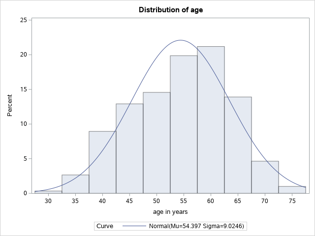

Histogram of numerical variable

The UNIVARIATE Procedure

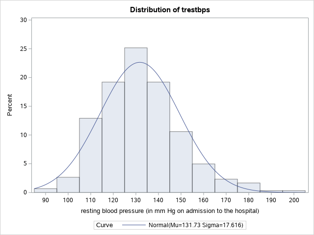

Histogram of numerical variable

The UNIVARIATE Procedure

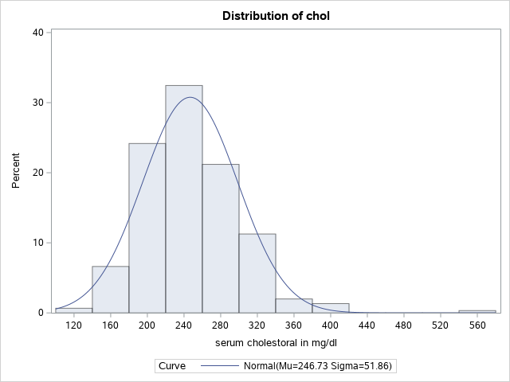

Histogram of numerical variable

The UNIVARIATE Procedure

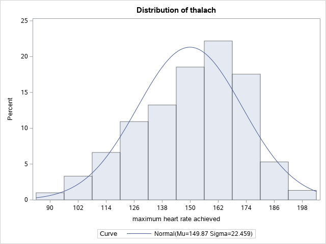

Histogram of numerical variable

The UNIVARIATE Procedure

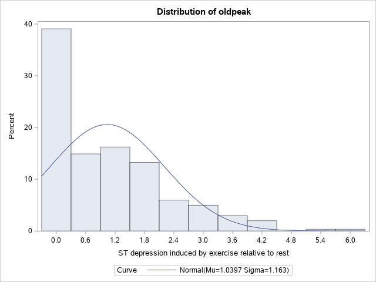

```sas
ods select histogram;
title "Histogram of numerical variable";
proc univariate data = mylib.heart;
    id id;
    var age trestbps chol thalach oldpeak;
    Histogram / normal;
run;
```

Histogram, P-P plots and Q-Q plots of oldpeak

The UNIVARIATE Procedure

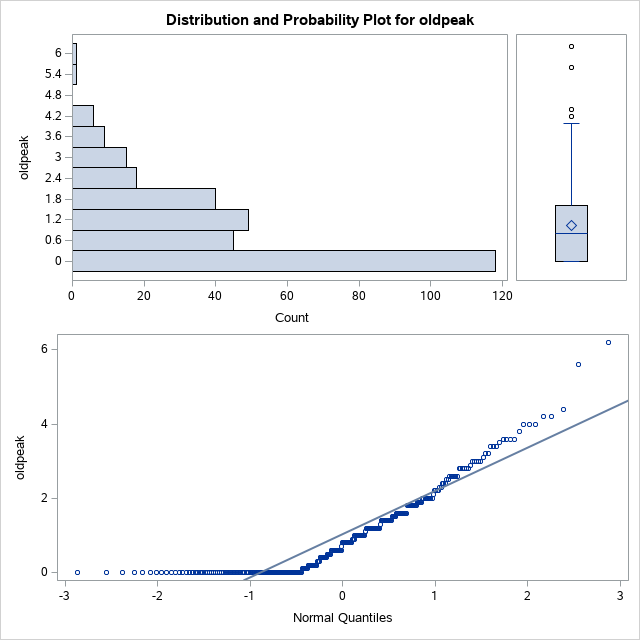

Histogram, P-P plots and Q-Q plots of oldpeak

The UNIVARIATE Procedure

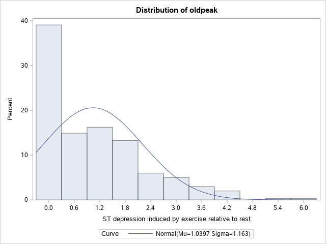

```sas
ods select histogram Plots;
title "Histogram, P-P plots and Q-Q plots of oldpeak";
proc univariate data = mylib.heart plot;
    id id;
    var oldpeak;
    Histogram / normal;
run;
```

comment: We can clearly see that the data points is far away from the straight line (which is normal data). Especialy for the lower end where we have nearly 40% of values is 0. Base on Q-Q plots we can conclude that oldpeak is highly right-skewed.

We apply log transformation (with min of oldpeak is 0), and quadratic root.

Histogram, P-P plots and Q-Q plots of log_oldpeak

The UNIVARIATE Procedure

Variable: log_oldpeak

| Tests for Normality Test | Tests for Normality Statistic | Tests for Normality Statistic | Tests for Normality p Value | Tests for Normality p Value |
| --- | --- | --- | --- | --- |
| Shapiro-Wilk | W | 0.939517 | Pr < W | <0.0001 |
| Kolmogorov-Smirnov | D | 0.123686 | Pr > D | <0.0100 |
| Cramer-von Mises | W-Sq | 0.546396 | Pr > W-Sq | <0.0050 |
| Anderson-Darling | A-Sq | 3.505673 | Pr > A-Sq | <0.0050 |

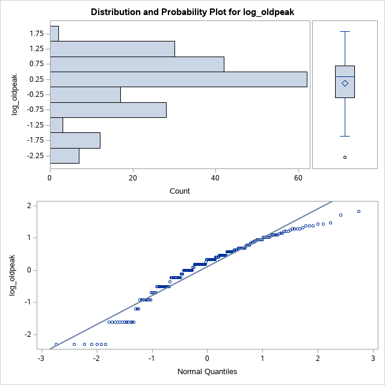

Histogram, P-P plots and Q-Q plots of log_oldpeak

The UNIVARIATE Procedure

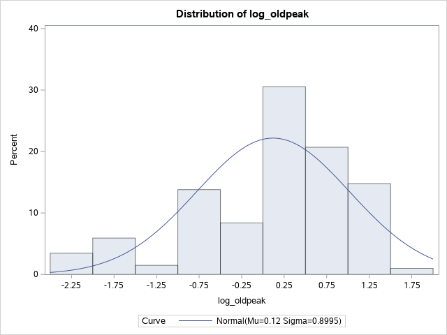

Histogram, P-P plots and Q-Q plots of log_oldpeak

The UNIVARIATE Procedure

Variable: root4_oldpeak

| Tests for Normality Test | Tests for Normality Statistic | Tests for Normality Statistic | Tests for Normality p Value | Tests for Normality p Value |
| --- | --- | --- | --- | --- |
| Shapiro-Wilk | W | 0.818928 | Pr < W | <0.0001 |
| Kolmogorov-Smirnov | D | 0.238538 | Pr > D | <0.0100 |
| Cramer-von Mises | W-Sq | 3.475643 | Pr > W-Sq | <0.0050 |
| Anderson-Darling | A-Sq | 22.95621 | Pr > A-Sq | <0.0050 |

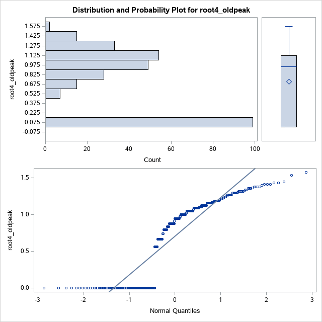

Histogram, P-P plots and Q-Q plots of log_oldpeak

The UNIVARIATE Procedure

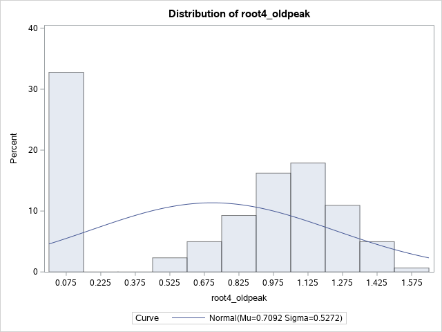

```sas
Data mylib.heart;
    SET mylib.heart;
    log_oldpeak = log(oldpeak);
    root4_oldpeak = (oldpeak) ** 0.25;
RUN;

ods select histogram Plots TestsForNormality;
title "Histogram, P-P plots and Q-Q plots of log_oldpeak";
proc univariate data = mylib.heart plot normal;
    id id;
    var log_oldpeak root4_oldpeak;
    Histogram / normal;
run;
```

After transformation using both method, data is still not qualified for normal distribution. Base on the W statistic from Shapiro-Wilk test, we can see that the log transformation is slightly better in this situation. In the Q-Q plots, for both case, a lot of points are not in the straight line, but for log_oldpeak, it seems to be more normal than root4_oldpeak.